**City College of San Francisco**

MATH 108 - Foundations of Data Science

# Lecture 05: Building Tables

Associated Textbook Sections: [5.0, 5.1, 5.2, 5.3](https://inferentialthinking.com/chapters/05/Sequences.html)

## Set Up the Notebook

```python
from datascience import *
import numpy as np
%matplotlib inline
import matplotlib.pyplot as plots
plots.style.use('fivethirtyeight')
```

# Table of Contents

## Arrays

### Demo: Columns of Tables are Arrays

Import the data on skyscrapers as a table and explore the San Francisco content of that table.

```python
skyscrapers = Table().read_table('skyscrapers_v2.csv')
skyscrapers
```

| name | material | city | height | completed |
| --- | --- | --- | --- | --- |
| One World Trade Center | mixed/composite | New York City | 541.3 | 2014 |
| Willis Tower | steel | Chicago | 442.14 | 1974 |
| 432 Park Avenue | concrete | New York City | 425.5 | 2015 |
| Trump International Hotel & Tower | concrete | Chicago | 423.22 | 2009 |
| Empire State Building | steel | New York City | 381 | 1931 |
| Bank of America Tower | mixed/composite | New York City | 365.8 | 2009 |
| Stratosphere Tower | concrete | Las Vegas | 350.22 | 1996 |
| Aon Center | steel | Chicago | 346.26 | 1973 |
| John Hancock Center | steel | Chicago | 343.69 | 1969 |
| Chrysler Building | steel | New York City | 318.9 | 1930 |

... (1771 rows omitted)

```python
sf = skyscrapers.where("city", "San Francisco")
sf
```

| name | material | city | height | completed |
| --- | --- | --- | --- | --- |
| Transamerica Pyramid | mixed/composite | San Francisco | 260 | 1972 |
| 555 California Street | steel | San Francisco | 237.44 | 1969 |
| 345 California Center | steel | San Francisco | 211.84 | 1986 |
| Millennium Tower | concrete | San Francisco | 196.6 | 2009 |
| One Rincon Hill South Tower | concrete | San Francisco | 184.41 | 2008 |
| 101 California Street | steel | San Francisco | 183 | 1982 |
| 50 Fremont Center | steel | San Francisco | 183 | 1985 |
| Chevron Tower | steel | San Francisco | 174.65 | 1975 |
| Four Embarcadero Center | steel | San Francisco | 173.74 | 1984 |
| One Embarcadero Center | steel | San Francisco | 173.43 | 1970 |

... (51 rows omitted)

```python
sf.sort('completed', descending=True)
```

| name | material | city | height | completed |
| --- | --- | --- | --- | --- |
| 535 Mission Street | mixed/composite | San Francisco | 115.37 | 2015 |
| 222 Second Street | mixed/composite | San Francisco | 112.78 | 2015 |
| One Rincon Hill North Tower | steel | San Francisco | 165 | 2014 |
| Millennium Tower | concrete | San Francisco | 196.6 | 2009 |
| The Infinity II | concrete | San Francisco | 128.02 | 2009 |
| One Rincon Hill South Tower | concrete | San Francisco | 184.41 | 2008 |
| 555 Mission Street | steel | San Francisco | 148.44 | 2008 |
| The Infinity I | concrete | San Francisco | 106.7 | 2008 |
| San Francisco Federal Building | concrete | San Francisco | 71.32 | 2007 |
| St. Regis San Francisco | concrete | San Francisco | 147.53 | 2005 |

... (51 rows omitted)

```python
sf.select('height')
```

| height |
| --- |
| 260 |
| 237.44 |
| 211.84 |
| 196.6 |
| 184.41 |
| 183 |
| 183 |
| 174.65 |
| 173.74 |
| 173.43 |

... (51 rows omitted)

```python
# numpy wants to work with arrays, not tables!
np.average(sf.select('height'))
```

```
---------------------------------------------------------------------------
ValueError                                Traceback (most recent call last)
Input In [6], in <module>
      1 # numpy wants to work with arrays, not tables!
----> 2 np.average(sf.select('height'))

File <__array_function__ internals>:180, in average(*args, **kwargs)

File /opt/conda/lib/python3.9/site-packages/numpy/lib/function_base.py:492, in average(a, axis, weights, returned)
    395 @array_function_dispatch(_average_dispatcher)
    396 def average(a, axis=None, weights=None, returned=False):
    397     """
    398     Compute the weighted average along the specified axis.
    399
   (...)
    490     complex256
    491     """
--> 492     a = np.asanyarray(a)
    494     if weights is None:
    495         avg = a.mean(axis)

ValueError: invalid __array_struct__
```

```python
sf.column('height')
```

[output not shown]

```python
np.average(sf.column('height'))
```

[output not shown]

```python
np.median(sf.column('height'))
```

[output not shown]

The demonstrated method to add a row of information to a table is destructive. Be care when you use they kinds of operations. Always check the documentation.

```python
# The data type of the height values
type(sf.column('height').item(0))
```

[output not shown]

```python
# append is a "destructive" method as it changes the actual table
sf_with_SFT = sf.copy()
sf_with_SFT.append(['Salesforce Tower', 'steel', 'San Francisco', 1070.0, 2018])
```

```python
sf_with_SFT = sf_with_SFT.sort('completed', descending=True)
sf_with_SFT
```

[output not shown]

```python
np.average(sf_with_SFT.column('height'))
```

[output not shown]

```python
np.median(sf_with_SFT.column('height'))
```

[output not shown]

## Ranges

### Ranges

- A range is an array of consecutive numbers
  - `np.arange(stop)`: An array of increasing integers from `0` up to `stop`
  - `np.arange(start, stop)`: An array of increasing integers from `start` up to `stop`
  - `np.arange(start, stop, step)`: A range with step between consecutive values
- The range always includes `start` but excludes `stop`

### Demo: Ranges

Make an array explicitly using `make_array` and then construct it and several others using `np.arange`. Access items in an array using the `item` method. Explore the documentation for `np.arange` and force some common errors.

For those with experience using Python arrays, keep in mind that this course does not use the bracket notation `[]` to access items in an array and that may trigger an error in the auto-grader on assignments.

```python
make_array(0, 1, 2, 3, 4, 5, 6, 7, 8, 9)
```

[output not shown]

$[0, 10)$

```python
np.arange(10)
```

[output not shown]

```python
np.arange(2, 31)
```

[output not shown]

```python
np.arange(2, 31, 2)
```

[output not shown]

```python
np.arange(2, 31, 0.1)
```

```
array([ 2. ,  2.1,  2.2,  2.3,  2.4,  2.5,  2.6,  2.7,  2.8,  2.9,  3. ,
        3.1,  3.2,  3.3,  3.4,  3.5,  3.6,  3.7,  3.8,  3.9,  4. ,  4.1,
        4.2,  4.3,  4.4,  4.5,  4.6,  4.7,  4.8,  4.9,  5. ,  5.1,  5.2,
        5.3,  5.4,  5.5,  5.6,  5.7,  5.8,  5.9,  6. ,  6.1,  6.2,  6.3,
        6.4,  6.5,  6.6,  6.7,  6.8,  6.9,  7. ,  7.1,  7.2,  7.3,  7.4,
        7.5,  7.6,  7.7,  7.8,  7.9,  8. ,  8.1,  8.2,  8.3,  8.4,  8.5,
        8.6,  8.7,  8.8,  8.9,  9. ,  9.1,  9.2,  9.3,  9.4,  9.5,  9.6,
        9.7,  9.8,  9.9, 10. , 10.1, 10.2, 10.3, 10.4, 10.5, 10.6, 10.7,
       10.8, 10.9, 11. , 11.1, 11.2, 11.3, 11.4, 11.5, 11.6, 11.7, 11.8,
       11.9, 12. , 12.1, 12.2, 12.3, 12.4, 12.5, 12.6, 12.7, 12.8, 12.9,
       13. , 13.1, 13.2, 13.3, 13.4, 13.5, 13.6, 13.7, 13.8, 13.9, 14. ,
       14.1, 14.2, 14.3, 14.4, 14.5, 14.6, 14.7, 14.8, 14.9, 15. , 15.1,
       15.2, 15.3, 15.4, 15.5, 15.6, 15.7, 15.8, 15.9, 16. , 16.1, 16.2,
       16.3, 16.4, 16.5, 16.6, 16.7, 16.8, 16.9, 17. , 17.1, 17.2, 17.3,
       17.4, 17.5, 17.6, 17.7, 17.8, 17.9, 18. , 18.1, 18.2, 18.3, 18.4,
       18.5, 18.6, 18.7, 18.8, 18.9, 19. , 19.1, 19.2, 19.3, 19.4, 19.5,
       19.6, 19.7, 19.8, 19.9, 20. , 20.1, 20.2, 20.3, 20.4, 20.5, 20.6,
       20.7, 20.8, 20.9, 21. , 21.1, 21.2, 21.3, 21.4, 21.5, 21.6, 21.7,
       21.8, 21.9, 22. , 22.1, 22.2, 22.3, 22.4, 22.5, 22.6, 22.7, 22.8,
       22.9, 23. , 23.1, 23.2, 23.3, 23.4, 23.5, 23.6, 23.7, 23.8, 23.9,
       24. , 24.1, 24.2, 24.3, 24.4, 24.5, 24.6, 24.7, 24.8, 24.9, 25. ,
       25.1, 25.2, 25.3, 25.4, 25.5, 25.6, 25.7, 25.8, 25.9, 26. , 26.1,
       26.2, 26.3, 26.4, 26.5, 26.6, 26.7, 26.8, 26.9, 27. , 27.1, 27.2,
       27.3, 27.4, 27.5, 27.6, 27.7, 27.8, 27.9, 28. , 28.1, 28.2, 28.3,
       28.4, 28.5, 28.6, 28.7, 28.8, 28.9, 29. , 29.1, 29.2, 29.3, 29.4,
       29.5, 29.6, 29.7, 29.8, 29.9, 30. , 30.1, 30.2, 30.3, 30.4, 30.5,
       30.6, 30.7, 30.8, 30.9])
```

### Ways to Create a Table

- `Table.read_table(filename)` - reads a table from a spreadsheet
- `Table()` - an empty table
- and… `select`, `drop`, `where`, `sort` and a few other table methods all create new tables

### Demo: Creating a Table from Scratch

Create a table containing information on the major east-west streets north of the Ocean campus and how far they are from campus. Make sure how to see that most table methods will end up creating a new table and not modify the original one.

[Google Maps near CCSF - Ocean Campus](https://goo.gl/maps/QVR57VvqKWqLeSA9A)

```python
streets = make_array('Judson', 'Staples', 'Flood', 'Hearst')
northside = Table().with_columns('Streets', streets)
northside
```

| Streets |
| --- |
| Judson |
| Staples |
| Flood |
| Hearst |

```python
northside = northside.with_columns('Distance from campus', np.arange(4))
northside
```

| Streets | Distance from campus |
| --- | --- |
| Judson | 0 |
| Staples | 1 |
| Flood | 2 |
| Hearst | 3 |

```python
northside.labels
```

```
('Streets', 'Distance from campus')
```

```python
northside.num_rows
```

```
4
```

```python
northside.num_columns
```

```
2
```

## Example: W. E. B. Du Bois

Image Source: [Wikipedia - W. E. B. Du Bois](https://en.wikipedia.org/wiki/W._E._B._Du_Bois)

[figure not shown]

- Scholar, historian, activist, and data scientist
- NAACP founder
- Made a series of visualizations for the 1900 Paris Exposition
  - Goal: change the way people see Black Americans
  - Hundreds of photographs and patents
  - 60+ handmade graphs in 3 months

Image Sources:

- [Smithsonian Magazine - W.E.B. Du Bois’ Visionary Infographics Come Together for the First Time in Full Color](https://www.smithsonianmag.com/history/first-time-together-and-color-book-displays-web-du-bois-visionary-infographics-180970826/#)
- [WBUR - W.E.B. Du Bois Created These Infographics In 1900 To Humanize The African-American Experience](https://www.wbur.org/news/2019/02/21/web-du-bois-infographics-humanity-african-american)

[figure not shown]

### Demo: Reading a Table from a File

Read the `du_bois.csv` data as a table.

```python
du_bois = Table().read_table('du_bois.csv')
du_bois.show(2)
```

| CLASS | ACTUAL AVERAGE | RENT | FOOD | CLOTHES | TAXES | OTHER | STATUS |
| --- | --- | --- | --- | --- | --- | --- | --- |
| 100-200 | 139.1 | 0.19 | 0.43 | 0.28 | 0.001 | 0.099 | POOR |
| 200-300 | 249.45 | 0.22 | 0.47 | 0.23 | 0.04 | 0.04 | POOR |

... (5 rows omitted)

Find the income bracket (`CLASS`) that spent the highest percentage of their income on rent.

```python
# We count starting with 0, not 1.
du_bois.sort('RENT', descending=True).column('CLASS').item(0)
```

```
'300-400'
```

Explore the table using `select`, `column`

```python
du_bois
```

| CLASS | ACTUAL AVERAGE | RENT | FOOD | CLOTHES | TAXES | OTHER | STATUS |
| --- | --- | --- | --- | --- | --- | --- | --- |
| 100-200 | 139.1 | 0.19 | 0.43 | 0.28 | 0.001 | 0.099 | POOR |
| 200-300 | 249.45 | 0.22 | 0.47 | 0.23 | 0.04 | 0.04 | POOR |
| 300-400 | 335.66 | 0.23 | 0.43 | 0.18 | 0.045 | 0.115 | FAIR |
| 400-500 | 433.82 | 0.18 | 0.37 | 0.15 | 0.055 | 0.245 | FAIR |
| 500-750 | 547 | 0.13 | 0.31 | 0.17 | 0.05 | 0.34 | COMFORTABLE |
| 750-1000 | 880 | 0 | 0.37 | 0.19 | 0.08 | 0.36 | COMFORTABLE |
| 1000 and over | 1125 | 0 | 0.29 | 0.16 | 0.045 | 0.505 | WELL-TO-DO |

```python
du_bois.column('ACTUAL AVERAGE') * du_bois.column('RENT')
```

```
array([26.429 , 54.879 , 77.2018, 78.0876, 71.11  ,  0.    ,  0.    ])
```

Add a column to the table showing the dollar amount for food based on the presented average.

```python
food_dollars = du_bois.column('ACTUAL AVERAGE') * du_bois.column('FOOD')
du_bois = du_bois.with_columns('FOOD ($)', food_dollars)
du_bois
```

| CLASS | ACTUAL AVERAGE | RENT | FOOD | CLOTHES | TAXES | OTHER | STATUS | FOOD ($) |
| --- | --- | --- | --- | --- | --- | --- | --- | --- |
| 100-200 | 139.1 | 0.19 | 0.43 | 0.28 | 0.001 | 0.099 | POOR | 59.813 |
| 200-300 | 249.45 | 0.22 | 0.47 | 0.23 | 0.04 | 0.04 | POOR | 117.241 |
| 300-400 | 335.66 | 0.23 | 0.43 | 0.18 | 0.045 | 0.115 | FAIR | 144.334 |
| 400-500 | 433.82 | 0.18 | 0.37 | 0.15 | 0.055 | 0.245 | FAIR | 160.513 |
| 500-750 | 547 | 0.13 | 0.31 | 0.17 | 0.05 | 0.34 | COMFORTABLE | 169.57 |
| 750-1000 | 880 | 0 | 0.37 | 0.19 | 0.08 | 0.36 | COMFORTABLE | 325.6 |
| 1000 and over | 1125 | 0 | 0.29 | 0.16 | 0.045 | 0.505 | WELL-TO-DO | 326.25 |

Format the `Food` column as a percent using the `set_format` method.

```python
du_bois = du_bois.set_format('FOOD', PercentFormatter)
du_bois
```

| CLASS | ACTUAL AVERAGE | RENT | FOOD | CLOTHES | TAXES | OTHER | STATUS | FOOD ($) |
| --- | --- | --- | --- | --- | --- | --- | --- | --- |
| 100-200 | 139.1 | 0.19 | 43.00% | 0.28 | 0.001 | 0.099 | POOR | 59.813 |
| 200-300 | 249.45 | 0.22 | 47.00% | 0.23 | 0.04 | 0.04 | POOR | 117.241 |
| 300-400 | 335.66 | 0.23 | 43.00% | 0.18 | 0.045 | 0.115 | FAIR | 144.334 |
| 400-500 | 433.82 | 0.18 | 37.00% | 0.15 | 0.055 | 0.245 | FAIR | 160.513 |
| 500-750 | 547 | 0.13 | 31.00% | 0.17 | 0.05 | 0.34 | COMFORTABLE | 169.57 |
| 750-1000 | 880 | 0 | 37.00% | 0.19 | 0.08 | 0.36 | COMFORTABLE | 325.6 |
| 1000 and over | 1125 | 0 | 29.00% | 0.16 | 0.045 | 0.505 | WELL-TO-DO | 326.25 |

```python
du_bois.select(0) # Same as select('CLASS') because class is the first column.
```

| CLASS |
| --- |
| 100-200 |
| 200-300 |
| 300-400 |
| 400-500 |
| 500-750 |
| 750-1000 |
| 1000 and over |

```python
du_bois.select(0, 3, du_bois.num_columns - 1)
```

| CLASS | FOOD | FOOD ($) |
| --- | --- | --- |
| 100-200 | 43.00% | 59.813 |
| 200-300 | 47.00% | 117.241 |
| 300-400 | 43.00% | 144.334 |
| 400-500 | 37.00% | 160.513 |
| 500-750 | 31.00% | 169.57 |
| 750-1000 | 37.00% | 325.6 |
| 1000 and over | 29.00% | 326.25 |

```python
du_bois.select('CLASS', 'FOOD', 'FOOD ($)')
```

| CLASS | FOOD | FOOD ($) |
| --- | --- | --- |
| 100-200 | 43.00% | 59.813 |
| 200-300 | 47.00% | 117.241 |
| 300-400 | 43.00% | 144.334 |
| 400-500 | 37.00% | 160.513 |
| 500-750 | 31.00% | 169.57 |
| 750-1000 | 37.00% | 325.6 |
| 1000 and over | 29.00% | 326.25 |

### Table Methods

- Creating and extending tables: `Table().with_column` and `Table.read_table`
- Finding the size: `num_rows` and `num_columns`
- Referring to columns: labels, relabeling, and indices
  - `labels` and `relabeled`; column indices start at 0
- Accessing data in a column: `column` takes a label or index and returns an array
- Using array methods to work with data in columns: `item`, `sum`, `min`, `max`, and so on
- Creating new tables containing some of the original columns: `select`, `drop`

### Demo: Selecting Data in a Column

Explore the `movies_by_year_with_ticket_price.csv` data set trying to implement several of the methods used so far. Also, preview the `plot` method.

```python
movies = Table.read_table('movies_by_year_with_ticket_price.csv')
movies.show()
```

| Year | Average Ticket Price | Total Gross | Number of Movies | #1 Movie |
| --- | --- | --- | --- | --- |
| 2019 | 9.16 | 11237.9 | 788 | Avengers: Endgame |
| 2018 | 9.11 | 11611.3 | 878 | Black Panther |
| 2017 | 8.97 | 11125.4 | 740 | Star Wars: Episode VIII - The Last Jedi |
| 2016 | 8.65 | 11373.7 | 737 | Rogue One: A Star Wars Story |
| 2015 | 8.43 | 11098.8 | 706 | Star Wars: Episode VII - The Force Awakens |
| 2014 | 8.17 | 10436.8 | 708 | American Sniper |
| 2013 | 8.13 | 10955.9 | 689 | The Hunger Games: Catching Fire |
| 2012 | 7.96 | 10959.6 | 669 | The Avengers |
| 2011 | 7.93 | 10114.1 | 601 | Harry Potter and the Deathly Hallows: Part 2 |
| 2010 | 7.89 | 10212.7 | 538 | Toy Story 3 |
| 2009 | 7.5 | 10821.6 | 520 | Avatar |
| 2008 | 7.18 | 9698.2 | 607 | The Dark Knight |
| 2007 | 6.88 | 9690.7 | 632 | Spider-Man 3 |
| 2006 | 6.55 | 9214.6 | 608 | Pirates of the Caribbean: Dead Man's Chest |
| 2005 | 6.41 | 8804.7 | 547 | Star Wars: Episode III - Revenge of the Sith |
| 2004 | 6.21 | 9321.7 | 551 | Shrek 2 |
| 2003 | 6.03 | 9057.5 | 506 | The Lord of the Rings: The Return of the King |
| 2002 | 5.8 | 9206.4 | 480 | Spider-Man |
| 2001 | 5.65 | 8070 | 356 | Harry Potter and the Sorcerer's Stone |
| 2000 | 5.39 | 7678.3 | 371 | How the Grinch Stole Christmas |
| 1999 | 5.06 | 7316.7 | 385 | Star Wars: Episode I - The Phantom Menace |
| 1998 | 4.69 | 6575.8 | 336 | Saving Private Ryan |
| 1997 | 4.59 | 6671.8 | 303 | Titanic |
| 1996 | 4.42 | 5706.7 | 310 | Independence Day |
| 1995 | 4.35 | 5383.5 | 279 | Toy Story |
| 1994 | 4.08 | 5079.2 | 254 | Forrest Gump |
| 1993 | 4.14 | 4983.2 | 258 | Jurassic Park |
| 1992 | 4.15 | 4603.9 | 234 | Aladdin |
| 1991 | 4.21 | 4313.9 | 244 | Terminator 2: Judgment Day |
| 1990 | 4.22 | 4527 | 224 | Home Alone |
| 1989 | 3.99 | 4155.4 | 236 | Batman |
| 1988 | 4.11 | 3565.8 | 248 | Rain Man |
| 1987 | 3.91 | 3562.9 | 232 | Three Men and a Baby |
| 1986 | 3.71 | 3200.5 | 207 | Top Gun |
| 1985 | 3.55 | 3056.4 | 180 | Back to the Future |
| 1984 | 3.36 | 3347.7 | 165 | Beverly Hills Cop |
| 1983 | 3.15 | 2652.9 | 158 | Star Wars: Episode VI - Return of the Jedi |
| 1982 | 2.94 | 2866.2 | 131 | E.T. the Extra-Terrestrial |
| 1981 | 2.78 | 2281.9 | 112 | Raiders of the Lost Ark |
| 1980 | 2.69 | 2299 | 115 | Star Wars: Episode V - The Empire Strikes Back |
| 1979 | 2.47 | 1957.5 | 83 | Kramer vs. Kramer |
| 1978 | 2.34 | 1552.3 | 55 | Grease |
| 1977 | 2.23 | 1373.1 | 35 | Star Wars: Episode IV - A New Hope |

```python
gross_in_dollars = movies.column('Total Gross') * 1e6
tix_sold = gross_in_dollars / movies.column('Average Ticket Price')
```

```python
movies = movies.with_column('Tickets sold', tix_sold)
```

```python
movies.show(4)
```

| Year | Average Ticket Price | Total Gross | Number of Movies | #1 Movie | Tickets sold |
| --- | --- | --- | --- | --- | --- |
| 2019 | 9.16 | 11237.9 | 788 | Avengers: Endgame | 1.22684e+09 |
| 2018 | 9.11 | 11611.3 | 878 | Black Panther | 1.27457e+09 |
| 2017 | 8.97 | 11125.4 | 740 | Star Wars: Episode VIII - The Last Jedi | 1.24029e+09 |
| 2016 | 8.65 | 11373.7 | 737 | Rogue One: A Star Wars Story | 1.31488e+09 |

... (39 rows omitted)

```python
movies.set_format('Tickets sold', NumberFormatter)
```

| Year | Average Ticket Price | Total Gross | Number of Movies | #1 Movie | Tickets sold |
| --- | --- | --- | --- | --- | --- |
| 2019 | 9.16 | 11237.9 | 788 | Avengers: Endgame | 1,226,844,978.17 |
| 2018 | 9.11 | 11611.3 | 878 | Black Panther | 1,274,566,410.54 |
| 2017 | 8.97 | 11125.4 | 740 | Star Wars: Episode VIII - The Last Jedi | 1,240,289,855.07 |
| 2016 | 8.65 | 11373.7 | 737 | Rogue One: A Star Wars Story | 1,314,878,612.72 |
| 2015 | 8.43 | 11098.8 | 706 | Star Wars: Episode VII - The Force Awakens | 1,316,583,629.89 |
| 2014 | 8.17 | 10436.8 | 708 | American Sniper | 1,277,454,100.37 |
| 2013 | 8.13 | 10955.9 | 689 | The Hunger Games: Catching Fire | 1,347,589,175.89 |
| 2012 | 7.96 | 10959.6 | 669 | The Avengers | 1,376,834,170.85 |
| 2011 | 7.93 | 10114.1 | 601 | Harry Potter and the Deathly Hallows: Part 2 | 1,275,422,446.41 |
| 2010 | 7.89 | 10212.7 | 538 | Toy Story 3 | 1,294,385,297.85 |

... (33 rows omitted)

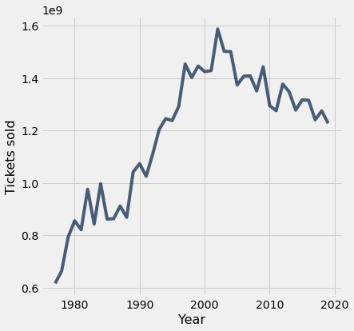

```python
movies.plot('Year', 'Tickets sold')
```

```python
movies.where('Year', are.between(2000, 2005))
```

| Year | Average Ticket Price | Total Gross | Number of Movies | #1 Movie | Tickets sold |
| --- | --- | --- | --- | --- | --- |
| 2004 | 6.21 | 9321.7 | 551 | Shrek 2 | 1,501,078,904.99 |
| 2003 | 6.03 | 9057.5 | 506 | The Lord of the Rings: The Return of the King | 1,502,072,968.49 |
| 2002 | 5.8 | 9206.4 | 480 | Spider-Man | 1,587,310,344.83 |
| 2001 | 5.65 | 8070 | 356 | Harry Potter and the Sorcerer's Stone | 1,428,318,584.07 |
| 2000 | 5.39 | 7678.3 | 371 | How the Grinch Stole Christmas | 1,424,545,454.55 |

```python
movies.where('Year', 2002)
```

| Year | Average Ticket Price | Total Gross | Number of Movies | #1 Movie | Tickets sold |
| --- | --- | --- | --- | --- | --- |
| 2002 | 5.8 | 9206.4 | 480 | Spider-Man | 1,587,310,344.83 |

```python
movies.where('Year', are.equal_to(2002))
```

| Year | Average Ticket Price | Total Gross | Number of Movies | #1 Movie | Tickets sold |
| --- | --- | --- | --- | --- | --- |
| 2002 | 5.8 | 9206.4 | 480 | Spider-Man | 1,587,310,344.83 |

```python
movies.where('#1 Movie', are.containing('Harry Potter'))
```

| Year | Average Ticket Price | Total Gross | Number of Movies | #1 Movie | Tickets sold |
| --- | --- | --- | --- | --- | --- |
| 2011 | 7.93 | 10114.1 | 601 | Harry Potter and the Deathly Hallows: Part 2 | 1,275,422,446.41 |
| 2001 | 5.65 | 8070 | 356 | Harry Potter and the Sorcerer's Stone | 1,428,318,584.07 |

```python
movies.take(np.arange(2, 5))
```

| Year | Average Ticket Price | Total Gross | Number of Movies | #1 Movie | Tickets sold |
| --- | --- | --- | --- | --- | --- |
| 2017 | 8.97 | 11125.4 | 740 | Star Wars: Episode VIII - The Last Jedi | 1,240,289,855.07 |
| 2016 | 8.65 | 11373.7 | 737 | Rogue One: A Star Wars Story | 1,314,878,612.72 |
| 2015 | 8.43 | 11098.8 | 706 | Star Wars: Episode VII - The Force Awakens | 1,316,583,629.89 |